# EBAIIn2 - ChIP-seq Workshop - Heatmaps

2021 May, 27th

## Heatmaps

Heatmap are widely used representation of ChIP-seq data as it allows visualization of read enrichment at various locations at the same time. For instance, one may want to represent read of its chipped protein enrichment +/-5Kb around all TSS of the reference genome or compare read enrichment at the same locations in many chip-seq datasets.

### Visualize BRG1 read enrichment at TSS

We can check if there is a tendency for the peaks to be located close to gene promoters. Here promoters are defined as regions +/-2Kb around the TSS.

First of all, for calculating the profile of ChIP peaks binding to TSS regions, we should prepare the TSS regions, which are defined as the flanking sequence of the TSS sites. Then align the peaks that are mapped to these regions, and generate the tagMatrix.

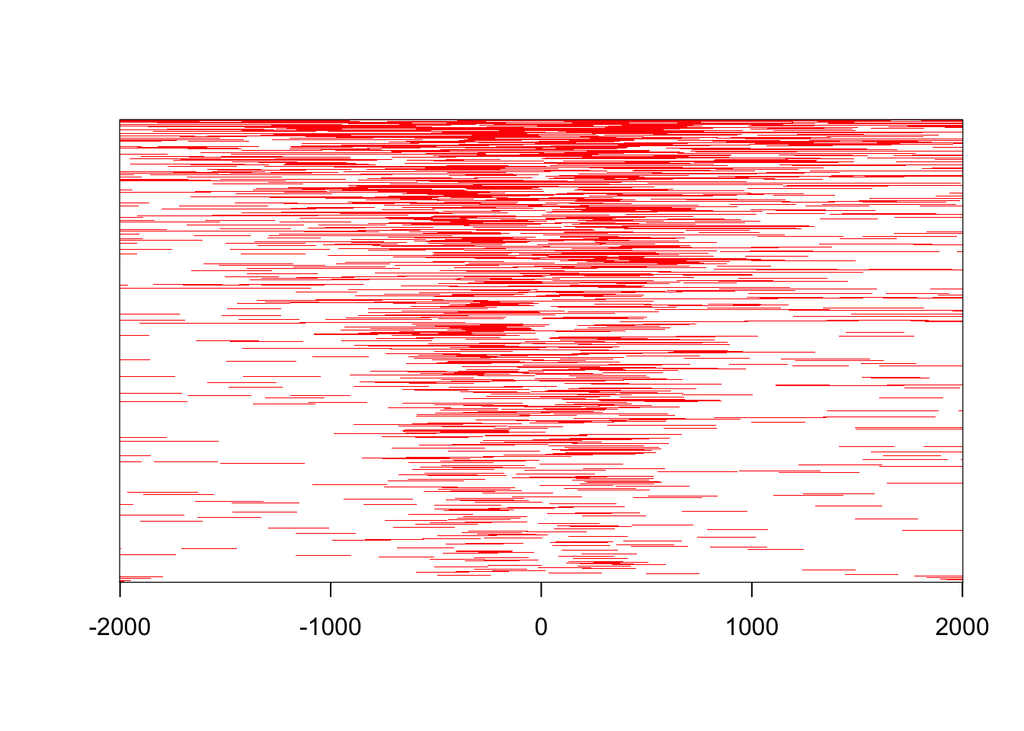

```r
## Load transcript annotation
library(TxDb.Hsapiens.UCSC.hg38.knownGene)
txdb <- TxDb.Hsapiens.UCSC.hg38.knownGene

## Load peaks
library(ChIPseeker)

peaks <- list()
peaks[["BRG1"]] <- readPeakFile(paste0(params$path.peaks, params$brg1), as="GRanges")

## define gene promoters
## TxDb object should be passed for peak annotation (see below)
promoter = getPromoters(TxDb=txdb, upstream=2000, downstream=2000)

## compute the density of peaks within the promoter regions
tagMatrix <- getTagMatrix(peaks$BRG1, windows=promoter)

## plot the density
tagHeatmap(tagMatrix, xlim=c(-2000, 2000), color="red")
```

Now look at the corresponding average profile.

```
## >> preparing promoter regions...  2021-05-18 13:09:09
## >> preparing tag matrix...        2021-05-18 13:09:09
## >> plotting figure...             2021-05-18 13:09:30
```

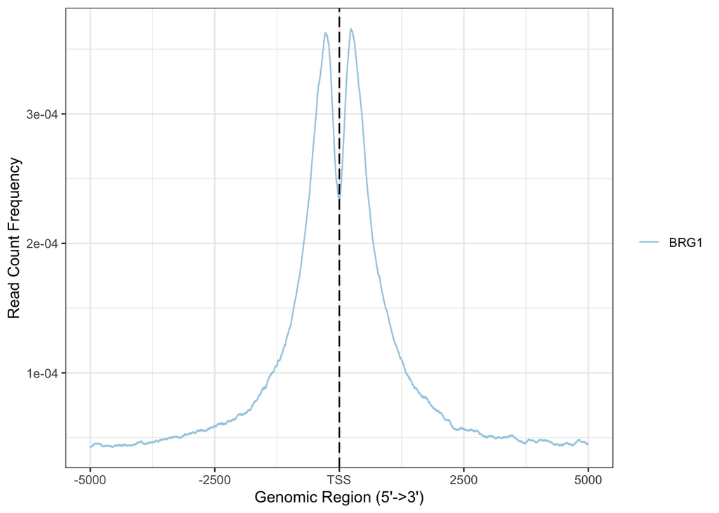

```r
plotAvgProf2(peaks, TxDb=txdb, upstream=5000, downstream=5000,
             xlab="Genomic Region (5'->3')", ylab = "Read Count Frequency")
```

The TxDb class is a container for storing transcript annotations. Bioconductor provides several packages containing TxDb objects for model organisms sur as Human and mouse. For instance, TxDb.Hsapiens.UCSC.hg38.knownGene, TxDb.Hsapiens.UCSC.hg19.knownGene for human genome hg38 and hg19, TxDb.Mmusculus.UCSC.mm10.knownGene and TxDb.Mmusculus.UCSC.mm9.knownGene for mouse genome mm10 and mm9, etc. User can also prepare their own TxDb by retrieving information from UCSC Genome Bioinformatics and BioMart data resources by R function makeTxDbFromBiomart and makeTxDbFromUCSC. One can also create a TxDb objects for his favourite organism using an annotation file in GTF/GFF format using the function makeTxDbFromGFF or the package GenomicFeatures.

```r
## download GTF file
download.file("https://ftp.ncbi.nlm.nih.gov/genomes/all/annotation_releases/93934/101/GCF_001577835.2_Coturnix_japonica_2.1/GCF_001577835.2_Coturnix_japonica_2.1_genomic.gtf.gz", "Coturnix_japonica_2.1.annotation.gtf.gz")

## Build TxDb object
library(GenomicFeatures)
txdb = makeTxDbFromGFF("Coturnix_japonica_2.1.annotation.gtf.gz")

## To save the txdb database
library(AnnotationDbi)
saveDb(txdb, 'txdb.Coturnix_japonica_2.1.sqlite')

## load it when needed
library(AnnotationDbi)
txdb = loadDb(file = 'txdb.Coturnix_japonica_2.1.sqlite')
```

### Are MITF and BRG1 co-localizing at MITF peak locations

To address this question, we are going to compute and visualize read enrichment at MITF peak location. Most of the time we look at regions centered at middles of peaks of interest and extended to 2/5Kb in both direction. To achieve this, we need :

- MITF peaks (narrowPeak file format)
- Signal tracks such as BigWig files for all datasets we want to visualize.

#### Prepare reference coordinates

We first need to load MITF peaks.

```r
## Loading peaks
peaks[["MITF"]] <- readPeakFile(paste0(params$path.peaks, params$mitf), as="GRanges")
```

Now, we prepare a GRange object that contains the regions of interest *i.e* positions of MITF peak centers +/-2Kb.

```r
features <- peaks$MITF
wid <- width(features)
feature.recentered <- feature.center <- features
start(feature.center) <- start(features) + floor(wid/2)
width(feature.center) <- 1
start(feature.recentered) <- start(feature.center) - 2000
end(feature.recentered) <- end(feature.center) + 2000
```

#### Prepare the signal matrices

We need to load bigwig files for all datasets that we want to visualize. Data are imported using a function from the rtracklayer package.

```r
library(rtracklayer)

cvglists <- sapply(file.path(params$path.bw,
                           c(params$brg1.bw, params$mitf.bw)),
                      import,
                      format="BigWig",
                      which=feature.recentered,
                      as="RleList")

cvglists
```

```
## $`/Users/slegras/Documents/Formations/EBAII/2021/ebaiin2/chip-seq/data//BRG1siCTRL_CHIP-seq.bw`
## RleList of length 25
## $chr1
## numeric-Rle of length 248956422 with 210878 runs
##   Lengths: 981874      1      5    123     26 ...      3     43     16 200511
##   Values :   0.00   0.49   0.81   0.32   0.81 ...   0.81   0.97   1.14   0.00
##
## $chr10
## numeric-Rle of length 133797422 with 71403 runs
##   Lengths: 456612     11      7      9      1 ...     85     46    154 263660
##   Values :   0.00   1.78   1.94   2.59   2.75 ...   0.16   0.00   0.16   0.00
##
## $chr11
## numeric-Rle of length 135086622 with 78287 runs
##   Lengths: 202632     37      7    107      3 ...     96     13      8 341418
##   Values :   0.00   0.32   0.65   0.49   0.32 ...   0.16   0.65   1.30   0.00
##
## $chr12
## numeric-Rle of length 133275309 with 74729 runs
##   Lengths:  51847     12     33     16     98 ...     30      4     53 235851
##   Values :   0.00   0.32   0.00   0.32   0.81 ...   0.16   0.33   0.16   0.00
##
## $chr13
## numeric-Rle of length 114364328 with 39047 runs
##   Lengths: 20104969       59      111       37 ...       23       79    33515
##   Values :     0.00     0.16     0.00     0.16 ...     0.32     0.16     0.00
##
## ...
## <20 more elements>
##
## $`/Users/slegras/Documents/Formations/EBAII/2021/ebaiin2/chip-seq/data//MITF_CHIP-seq.bw`
## RleList of length 25
## $chr1
## numeric-Rle of length 248956422 with 379872 runs
##   Lengths: 981874      8      7      6      8 ...      7     46      1 200511
##   Values :   0.00   0.74   0.64   0.53   0.64 ...   0.85   0.96   0.85   0.00
##
## $chr10
## numeric-Rle of length 133797422 with 160404 runs
##   Lengths: 456612      2      1      7     22 ...      4      1     20 263487
##   Values :   0.00   0.74   0.85   0.74   0.85 ...   1.17   1.28   1.49   0.00
##
## $chr11
## numeric-Rle of length 135086622 with 168561 runs
##   Lengths: 202632      8     12     47      3 ...     36    109     28 341548
##   Values :   0.00   1.17   1.28   1.38   1.28 ...   0.32   0.21   0.11   0.00
##
## $chr12
## numeric-Rle of length 133275309 with 151772 runs
##   Lengths:  51847     10     15     14      9 ...    211    135     38 235980
##   Values :   0.00   0.53   0.43   0.32   0.43 ...   0.11   0.21   0.11   0.00
##
## $chr13
## numeric-Rle of length 114364328 with 72431 runs
##   Lengths: 20104969       73       31       14 ...       35       16    33515
##   Values :     0.00     0.11     0.21     0.32 ...     0.32     0.43     0.00
##
## ...
## <20 more elements>
```

```r
## You can notice that names of entries in cvglists are full path to the data
## We are going to give shorter names
## if you know the order of each entry, you can set them like:
names(cvglists) <- c("BRG1", "MITF")
```

Now we can create matrices of read enrichments at the positions of interest. We are using functions from ChIPpeakAnno.

```r
library(ChIPpeakAnno)
sig <- featureAlignedSignal(cvglists, feature.recentered,
                           upstream=2000, downstream=2000)
lapply(sig, head)
```

```
## $BRG1
##                        [,1]  [,2]    [,3]    [,4]  [,5]    [,6]  [,7]    [,8]
## chr1:981875-985875   0.3855 0.320 0.32000 0.65975 0.490 0.57400 0.650 0.19675
## chr1:1077553-1081553 0.0000 0.000 0.00000 0.00000 0.000 0.00000 0.000 0.00000
## chr1:1302863-1306863 0.0000 0.000 0.00000 0.00000 0.076 0.49000 0.490 0.49000
## chr1:1334120-1338120 0.4180 0.144 0.28175 1.00200 1.290 1.47975 1.442 1.00000
## chr1:1439725-1443725 0.0000 0.000 0.00000 0.00000 0.000 0.16000 0.160 0.24000
## chr1:1565540-1569540 1.0180 1.713 3.36475 3.84800 3.844 3.33750 2.562 2.67800
##                         [,9]   [,10]   [,11]   [,12] [,13]   [,14] [,15]  [,16]
## chr1:981875-985875   0.16000 0.05200 0.00000 0.12800 0.365 1.01250 2.297 2.5300
## chr1:1077553-1081553 0.00000 0.00000 0.00000 0.00000 0.000 0.00000 0.000 0.0000
## chr1:1302863-1306863 0.33575 0.01200 0.16000 0.16000 0.160 0.12400 0.000 0.0000
## chr1:1334120-1338120 0.88200 0.88200 0.54350 0.32000 0.216 0.00000 0.000 0.0000
## chr1:1439725-1443725 0.29600 0.16000 0.16000 0.06825 0.490 0.49000 0.490 0.4655
## chr1:1565540-1569540 2.29800 2.20575 1.02825 0.85400 1.074 1.10425 1.808 1.5560
##                      [,17]   [,18]  [,19]   [,20]   [,21] [,22]   [,23]  [,24]
## chr1:981875-985875   2.314 1.52800 0.5820 0.18025 0.25375 0.874 0.81000 0.8100
## chr1:1077553-1081553 0.000 0.00000 0.0000 0.00000 0.00000 0.000 0.00000 0.0000
## chr1:1302863-1306863 0.000 0.14700 0.6180 0.71400 1.01400 1.074 0.87400 1.1780
## chr1:1334120-1338120 0.256 0.45175 0.6220 0.65000 0.64175 0.502 0.32425 0.2960
## chr1:1439725-1443725 0.490 0.49000 0.4900 0.44725 0.43900 0.630 0.65000 0.5725
## chr1:1565540-1569540 1.460 1.10075 1.2655 1.78400 3.62000 6.010 6.22650 7.4625
##                        [,25]   [,26]  [,27]   [,28]  [,29]   [,30]  [,31]
## chr1:981875-985875   0.75000 0.16825 0.4900 0.55000 0.8420 0.76200 0.4900
## chr1:1077553-1081553 0.00000 0.00000 0.0000 0.00000 0.0000 0.00000 0.0000
## chr1:1302863-1306863 0.87800 0.63000 0.3985 0.18800 0.7460 1.36625 1.6360
## chr1:1334120-1338120 0.00000 0.00000 0.0000 0.03200 0.3200 0.41350 0.4900
## chr1:1439725-1443725 1.04425 1.46000 1.5600 1.52550 1.6065 1.84000 2.3830
## chr1:1565540-1569540 5.85200 3.69400 3.5240 2.54625 1.9840 2.14675 1.2495
##                        [,32]   [,33]   [,34]   [,35]   [,36]   [,37]   [,38]
## chr1:981875-985875   0.39525 0.99075 1.91200 1.96475 2.25300 1.54850 1.36275
## chr1:1077553-1081553 0.21600 0.32000 0.32000 0.32000 0.05600 0.00000 0.00000
## chr1:1302863-1306863 1.84400 1.54425 1.34525 1.18200 0.83000 0.71400 0.58600
## chr1:1334120-1338120 0.85800 1.05000 1.17800 1.13000 0.55725 0.29000 0.16000
## chr1:1439725-1443725 2.79400 1.79725 1.81100 2.54125 6.70250 7.84775 7.39200
## chr1:1565540-1569540 1.45125 2.56175 6.15875 8.25000 8.89950 9.22700 8.05400
##                        [,39]   [,40]   [,41]    [,42]    [,43]    [,44]
## chr1:981875-985875   2.19325 2.47000 3.34325  4.07375  4.55075  6.12850
## chr1:1077553-1081553 0.00000 0.00000 0.00000  0.00000  0.00000  0.79350
## chr1:1302863-1306863 1.01400 1.17800 2.75175  5.58800  6.22175  8.34800
```

[output cut: 158 more lines]

```
## chr1:1565540-1569540 0.34200 0.20750 0.32000 0.32000 0.25125 0.30625 0.35575
##                        [,90]   [,91]   [,92]   [,93]   [,94]   [,95]   [,96]
## chr1:981875-985875   0.47350 0.17000 0.21775 0.61450 0.74000 0.81425 0.71975
## chr1:1077553-1081553 0.84175 0.78425 0.72075 0.73350 0.95025 1.09600 1.17025
## chr1:1302863-1306863 0.85900 0.96275 1.17000 1.11800 1.12875 1.10925 0.89300
## chr1:1334120-1338120 1.10800 0.95575 0.81975 0.70350 0.75450 1.08075 1.32275
## chr1:1439725-1443725 0.50250 0.59600 0.57400 0.64000 0.48250 0.20175 0.11000
## chr1:1565540-1569540 0.32550 0.43000 0.52525 0.53825 0.91400 0.94650 1.08675
##                        [,97]   [,98]   [,99]    [,100]
## chr1:981875-985875   0.39000 0.21000 0.16250 0.2973171
## chr1:1077553-1081553 1.19200 1.20300 1.02300 0.8370732
## chr1:1302863-1306863 1.94625 2.13650 2.29725 2.3202439
## chr1:1334120-1338120 1.45425 1.73575 1.45375 1.0824390
## chr1:1439725-1443725 0.01375 0.03025 0.17500 0.2100000
## chr1:1565540-1569540 1.09650 1.33725 2.33450 3.0082926
```

#### Create heatmaps

Let’s draw the heatmaps using the EnrichedHeatmap library.

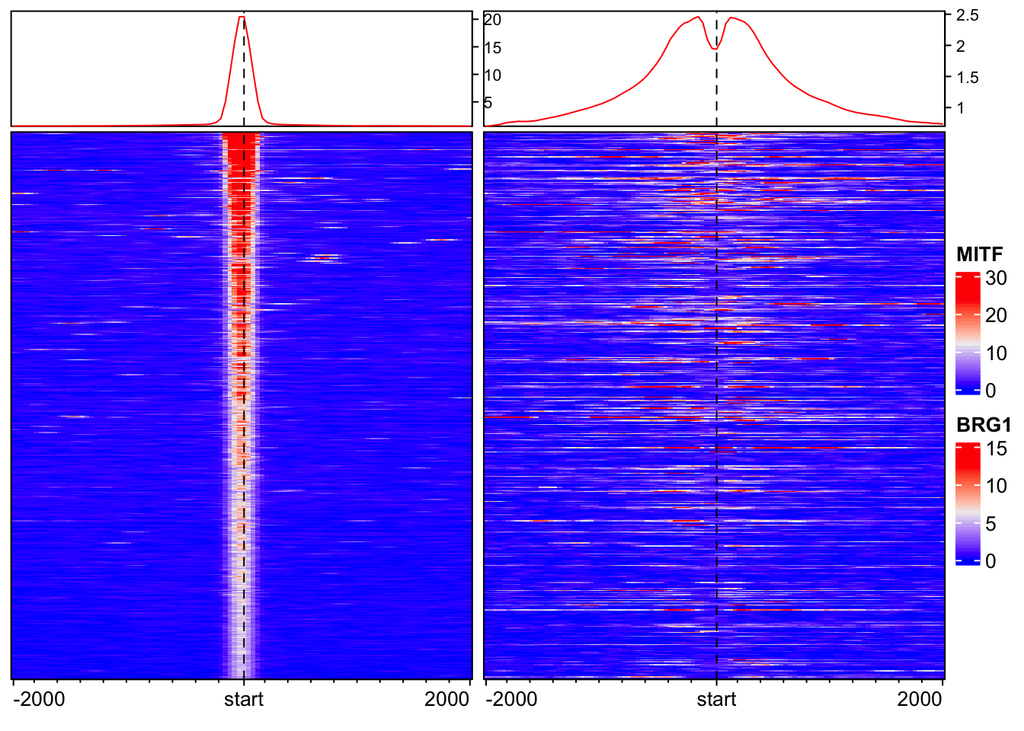

```r
## Load the library
library(EnrichedHeatmap)

## Create a list of normalizedMatrix that is the input format
## for EnrichedHeatmap
mat1 <- list()
mat1[["MITF"]] <- as.normalizedMatrix(as.matrix(sig[["MITF"]]),
    k_upstream = 50,
    k_downstream = 50,
    k_target = 0,
    extend = c(2000, 2000),
    signal_name = names(sig[["MITF"]]),
    target_name = "Peak centers"
)

mat1[["BRG1"]] <- as.normalizedMatrix(as.matrix(sig[["BRG1"]]),
    k_upstream = 50,
    k_downstream = 50,
    k_target = 0,
    extend = c(2000, 2000),
    signal_name = names(sig[["BRG1"]]),
    target_name = "Peak centers"
)

## Create the Heatmap with default parameters
EnrichedHeatmap(mat1$MITF, name = "MITF") +
EnrichedHeatmap(mat1$BRG1, name = "BRG1")
```

By default, heatmaps are sorted by read enrichment. However, it would be worth grouping together regions that have similar read enrichment. This can be done using a clustering method such as k-means. This type of clustering requires the number of expected clusters to be set. Moreover, to obtain reproductible clustering results, we need to set a seed.

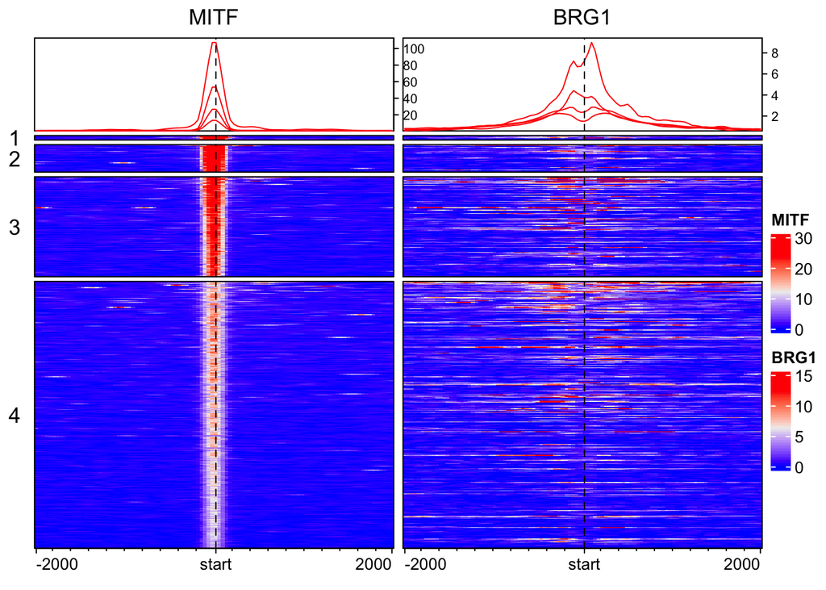

```r
## define a seed value to get the same results when re-running the analysis
set.seed(123)
## Create Heatmaps with k-means clustering on MITF data
EnrichedHeatmap(mat1$MITF, name = "MITF", row_km = 4,
    column_title = "MITF", row_title_rot = 0) +
EnrichedHeatmap(mat1$BRG1, name = "BRG1",
    column_title = "BRG1")
```

Let’s enhance it!

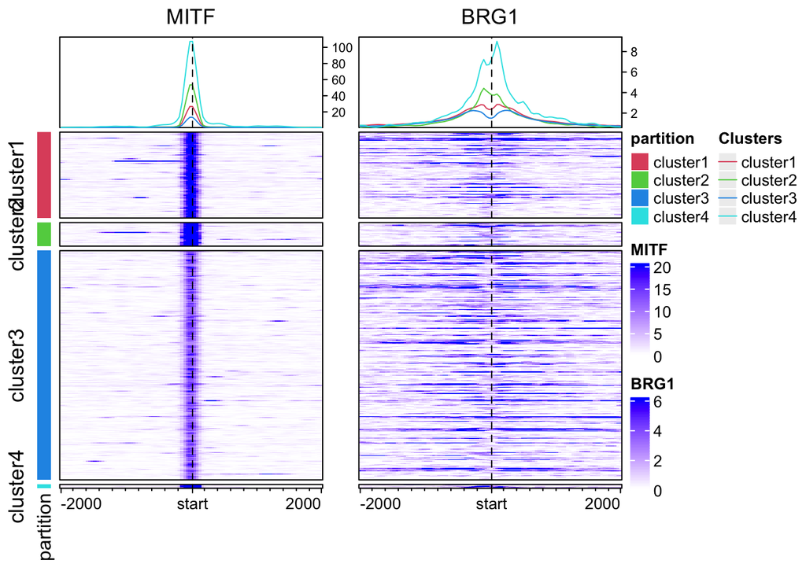

```r
library(circlize)
partition = paste0("cluster", kmeans(mat1$MITF, centers = 4)$cluster)
col_mitf = colorRamp2(c(0, 20), c("white", "blue"))
col_brg1 = colorRamp2(c(0, 6), c("white", "blue"))
lgd = Legend(at = c("cluster1", "cluster2", "cluster3", "cluster4"),
    title = "Clusters",
    type = "lines", legend_gp = gpar(col = 2:5))

ht_list = Heatmap(partition, col = structure(2:5, names = paste0("cluster", 1:4)), name = "partition", show_row_names = FALSE, width = unit(3, "mm")) +
EnrichedHeatmap(mat1$MITF, name = "MITF",
  top_annotation = HeatmapAnnotation(lines = anno_enriched(gp = gpar(col = 2:5))),
  column_title = "MITF", row_title_rot = 0, col=col_mitf) +
EnrichedHeatmap(mat1$BRG1, name = "BRG1", col=col_brg1,
  top_annotation = HeatmapAnnotation(lines = anno_enriched(gp = gpar(col = 2:5))),
  column_title = "BRG1")

draw(ht_list, split = partition, annotation_legend_list = list(lgd),
    ht_gap = unit(c(2, 8, 8), "mm"))
```